# Kaggle Facial Points Detection: Univ of Montreal: left_eye_center classification:: Faces_patch_clssfr_Pmnk

## Step `10.0: predict data new`

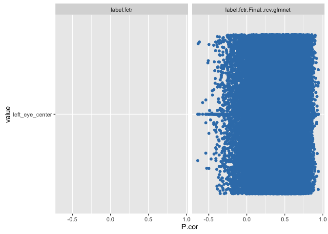

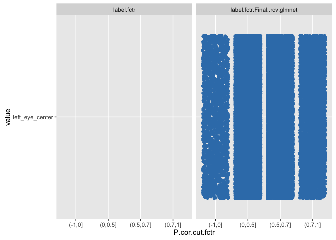

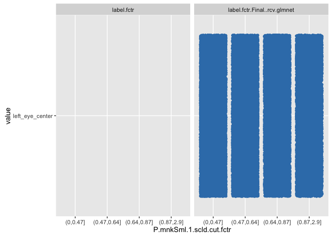

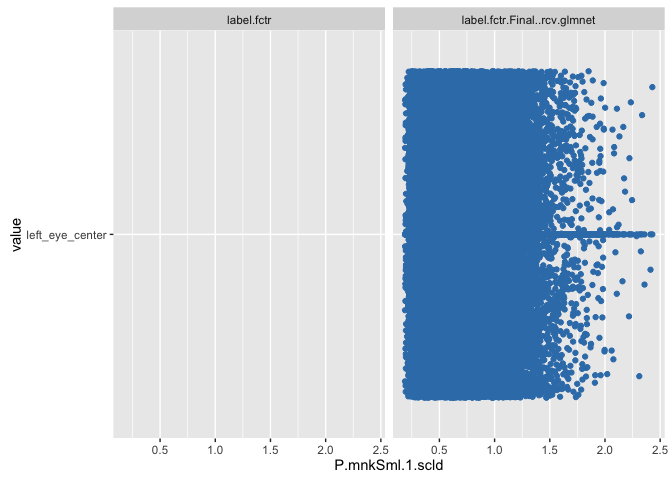

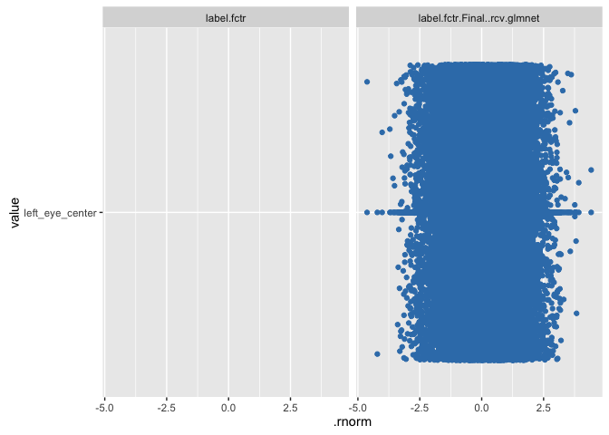

[output not shown]

[output cut: 77 more lines]

```
##       shapiro.test.p.value rsp_var_raw id_var rsp_var       max        min
## P.cor           4.2401e-35       FALSE     NA      NA 0.9417233 -0.7128218
##       max.label.fctr..none max.label.fctr.left_eye_center
## P.cor            0.9398131                      0.9269978
##       min.label.fctr..none min.label.fctr.left_eye_center
## P.cor           -0.7128218                     -0.6360407
##       max.label.fctr.All.X..rcv.glmnet.left_eye_center
## P.cor                                        0.9212727
##       min.label.fctr.All.X..rcv.glmnet.left_eye_center
## P.cor                                       -0.7128218
##       max.label.fctr.Final..rcv.glmnet.left_eye_center
## P.cor                                        0.9417233
##       min.label.fctr.Final..rcv.glmnet.left_eye_center
## P.cor                                       -0.6451595
## [1] "newobs total range outliers: 8"
```

```
## [1] 0
```

```
## [1] "glb_sel_mdl_id: All.X##rcv#glmnet"
```

```
## [1] "glb_fin_mdl_id: Final##rcv#glmnet"
```

```
## [1] "Cross Validation issues:"
## MFO###myMFO_classfr
##                   0
```